# Book Recommender and Shiny

Aashish Mandya Anilkumar

April 14, 2019

### **Table of Contents:**

```r
knitr::opts_chunk$set(warning = FALSE, message = FALSE)
###Install libraries##

list.of.packages <- c("recommenderlab","data.table","dplyr","tidyr","ggplot2","stringr","DT","knitr","grid","gridExtra","corrplot","qgraph","methods","Matrix","doParallel","tidyverse","caret","RColorBrewer","shinythemes","shiny","tableHTML","prettydoc")
#Specify the list of packages required for your project

new.packages <- list.of.packages[!(list.of.packages %in% installed.packages()[,"Package"])] #Check for the packages that are NOT installed in the system

if(length(new.packages)) install.packages(new.packages)
#Install the packages NOT installed in the system

###Loading libraries##
library(recommenderlab)
library(data.table)
library(dplyr)
library(tidyr)
library(ggplot2)
library(stringr)
library(DT)
library(knitr)
library(grid)
library(gridExtra)
library(corrplot)
library(qgraph)
library(methods)
library(Matrix)
library(doParallel)
library(tidyverse)
library(caret)
library(RColorBrewer)
library(shinythemes)
library(shiny)
library(tableHTML)
library(prettydoc)


###Reading in the dataset###
books <- fread("books.csv")
ratings <- fread("ratings.csv")
books_tags <- fread("book_tags.csv")
tags <- fread("tags.csv")
books_n <- fread("books_top.csv")
```

### **Part 1: Exploratory Analysis**

### 1.1 Data Structure:

Let’s have a look at what each of these datasets contain

```r
str(books)
str(ratings)
str(tags)
str(books_tags)
```

[output not shown]

**Insights:**

- Ratings dataset gives ushow each user has rated across all the books
- Books dataset contains information on books-the title,author,avg rating
- Book tags contain information of tags of the books while the tags dataset contains the title for each of these tags

### 1.2 Data Cleaning:

The data has been investigated for inaccuracies,missing values & duplicates

```r
ratings[, N := .N, .(user_id, book_id)]
r1 <- ratings[N == 1]

r1 <- r1 %>% group_by(user_id) %>% mutate(n = n())
r1 <- r1[r1$n>5,]
```

**Insights:**

- I see that duplicate ratings have been given by the same user for the same book,As a part of first step I am going to remove these duplicates
- I also see that some users have very less number of ratings, this could influence my model and hence I remove users who have rated less than 5 books

### 1.3 Data Partition:

I choose a sample of my dataset 20% of my users have been considered for the analysis

```r
set.seed(123)
user_fraction <- 0.2
users <- unique(r1$user_id)
sample_users <- sample(users, round(user_fraction * length(users)))
r2 <- r1[r1$user_id %in% sample_users,]
r2 <- r2[,c(1,2,3)]
```

### 1.4 Exploratory Data Analysis:

Understanding basic metrics and looking for some interesting patterns and trends in the data

```r
n_distinct(books$book_id)
```

```
## [1] 10000
```

```r
n_distinct(r1$user_id)
```

```
## [1] 32394
```

```r
n_distinct(books_tags$tag_id)
```

```
## [1] 34252
```

```r
n_distinct(books$authors)
```

```
## [1] 4664
```

**Insights:**

- We can see that we have a total of 10,000 books
- We have a total of 32394 users
- We have a toal of 34252 tags that these books are associated with
- We have a total of 4664 authors

### 1.41 How many books have my authors written:

I look at top 10 authors on the list

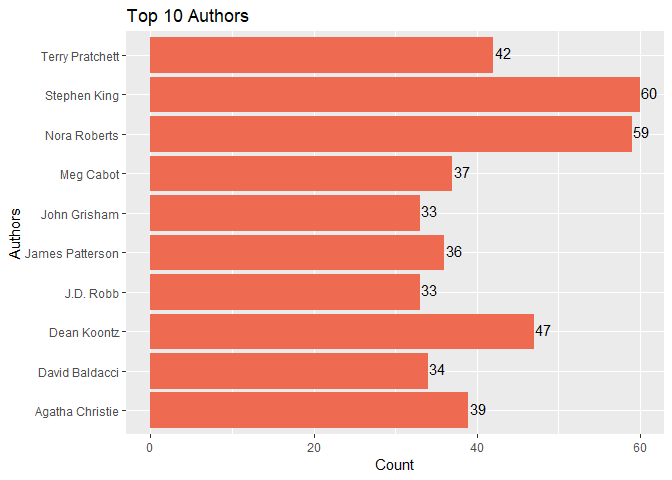

```r
auth <- books %>% group_by(authors) %>%
summarise(count=n()) %>%
arrange(desc(count)) %>% head(10)

ggplot(auth, aes(x = authors, y = count)) +
  geom_bar(fill = "coral2", stat = "identity") +
  geom_text(aes(label = count), vjust = 0.3,hjust=-0.1) + coord_flip()+
  labs( y="Count",
       x="Authors",
       title="Top 10 Authors")
```

**Insight:**

- Stephen King and Nora Roberts top the chart with 60 and 59 books respectively

### 1.42 What are my top rated books?

I look at top 10 rated books

```r
books  %>%
  mutate(image = paste0('<img src="', small_image_url, '"></img>')) %>%
arrange(desc(average_rating)) %>% head(10) %>% select(image,title,authors,average_rating,ratings_count) %>% datatable(class = "nowrap hover row-border", escape = FALSE, options = list(dom = 't',scrollX = TRUE, autoWidth = TRUE))
```

|  | image | title | authors | average_rating | ratings_count |
| --- | --- | --- | --- | --- | --- |
| 1 |  | The Complete Calvin and Hobbes | Bill Watterson | 4.82 | 28900 |
| 2 |  | Words of Radiance (The Stormlight Archive, #2) | Brandon Sanderson | 4.77 | 73572 |
| 3 |  | Harry Potter Boxed Set, Books 1-5 (Harry Potter, #1-5) | J.K. Rowling, Mary GrandPrÃ© | 4.77 | 33220 |
| 4 |  | ESV Study Bible | Anonymous, Lane T. Dennis, Wayne A. Grudem | 4.76 | 8953 |
| 5 |  | Mark of the Lion Trilogy | Francine Rivers | 4.76 | 9081 |
| 6 |  | It's a Magical World: A Calvin and Hobbes Collection | Bill Watterson | 4.75 | 22351 |
| 7 |  | Harry Potter Boxset (Harry Potter, #1-7) | J.K. Rowling | 4.74 | 190050 |
| 8 |  | There's Treasure Everywhere: A Calvin and Hobbes Collection | Bill Watterson | 4.74 | 16766 |
| 9 |  | Harry Potter Collection (Harry Potter, #1-6) | J.K. Rowling | 4.73 | 24618 |
| 10 |  | The Authoritative Calvin and Hobbes: A Calvin and Hobbes Treasury | Bill Watterson | 4.73 | 16087 |

**Insight:**

- ‘The complete Calvin and Hobes’ is the highest rated book with 4.82 followed by ‘Words of randiance’ with 4.77

### 1.43 What are my top popular books?

I look at the books which have got the highest number of ratings

```r
books  %>%
  mutate(image = paste0('<img src="', small_image_url, '"></img>')) %>%
arrange(desc(ratings_count)) %>% head(10) %>% select(image,title,authors,average_rating,ratings_count) %>% datatable(class = "nowrap hover row-border", escape = FALSE, options = list(dom = 't',scrollX = TRUE, autoWidth = TRUE))
```

|  | image | title | authors | average_rating | ratings_count |
| --- | --- | --- | --- | --- | --- |
| 1 |  | The Hunger Games (The Hunger Games, #1) | Suzanne Collins | 4.34 | 4780653 |
| 2 |  | Harry Potter and the Sorcerer's Stone (Harry Potter, #1) | J.K. Rowling, Mary GrandPrÃ© | 4.44 | 4602479 |
| 3 |  | Twilight (Twilight, #1) | Stephenie Meyer | 3.57 | 3866839 |
| 4 |  | To Kill a Mockingbird | Harper Lee | 4.25 | 3198671 |
| 5 |  | The Great Gatsby | F. Scott Fitzgerald | 3.89 | 2683664 |
| 6 |  | The Fault in Our Stars | John Green | 4.26 | 2346404 |
| 7 |  | The Hobbit | J.R.R. Tolkien | 4.25 | 2071616 |
| 8 |  | The Catcher in the Rye | J.D. Salinger | 3.79 | 2044241 |
| 9 |  | Pride and Prejudice | Jane Austen | 4.24 | 2035490 |
| 10 |  | Angels & Demons (Robert Langdon, #1) | Dan Brown | 3.85 | 2001311 |

**Insight:**

- ‘The Hunger Games’ is the most popular book with follwed by ‘Harry potter and the Sorcerer’s stone’

**Observation:**

- When we compare the two Analysis above, it shows us that popularity is not essentially quality

### 1.44 How are my ratings?

Here the ratings are counted to understand where my ratings stand

```r
options(scipen=10000)

r2 %>% group_by(rating) %>% summarise(count=n())
```

```
## # A tibble: 5 x 2
##   rating count
##    <int> <int>
## 1      1  3508
## 2      2 11759
## 3      3 46411
## 4      4 66291
## 5      5 54887
```

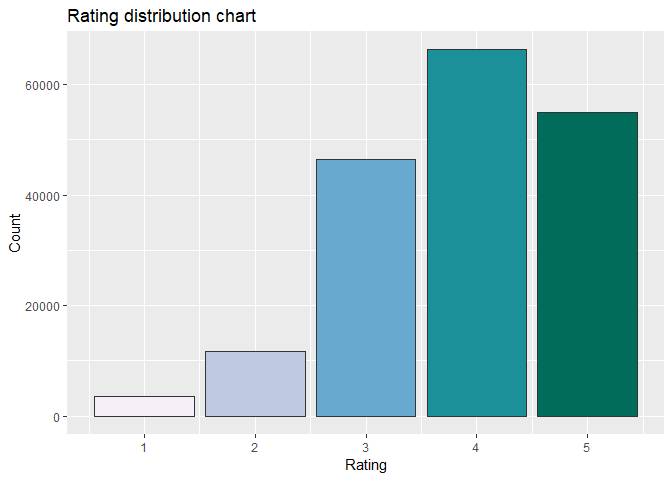

```r
r2 %>%
  ggplot(aes(x = rating, fill = factor(rating))) +
  geom_bar(color = "grey20") + scale_fill_brewer(palette = "PuBuGn") + guides(fill = FALSE)+ labs( y="Count", x="Rating", title="Rating distribution chart")
```

**Insight:**

- We see that people tend to give positive rating for the books with 4 being the highest number of ratings given. About 90% of the ratings fall between 3-5

### 1.45 Lets see how many ratings each of my customers give

This is to understand the activity of my users

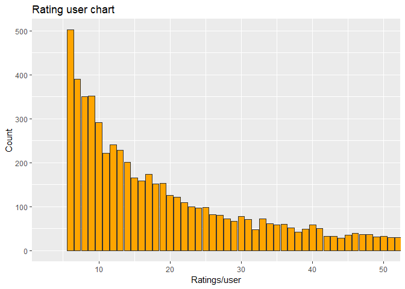

```r
a <- r2 %>%
  group_by(user_id) %>%
  summarize(no_of_ratings_per_user = n())
r2 %>%
  group_by(user_id) %>%
  summarize(no_of_ratings_per_user = n()) %>%
  ggplot(aes(no_of_ratings_per_user)) +
  geom_bar(fill = "orange", color = "grey20") + coord_cartesian(c(3, 50))+labs( y="Count", x="Ratings/user", title="Rating user chart")
```

**Insight:**

- This graph shows us that there are a lot of users who give less number of ratings compared to a few users who give high number of ratings. We can use this to compare the activity between users later in the model

### 1.46 Distribution of mean user rating

This is done to understand if people have different tendencies to rate books

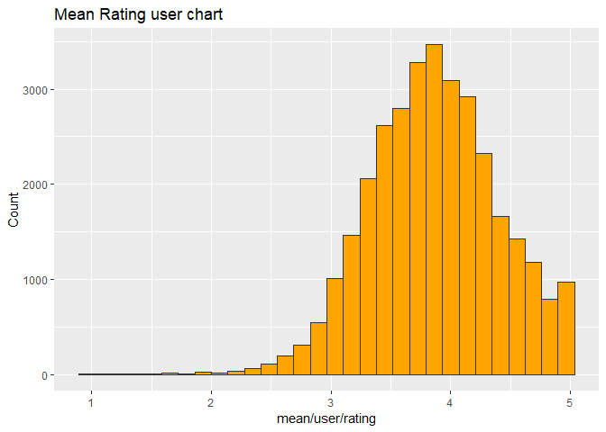

```r
r1 %>%
  group_by(user_id) %>%
  summarize(m = mean(rating)) %>%
  ggplot(aes(m)) +
  geom_histogram(fill = "orange", color = "grey20") +labs( y="Count", x="mean/user/rating", title="Mean Rating user chart")
```

**Insight:**

- People differ from each other.Some give 5 to a mediocre book others give 5 only to the books that are perfect for them.Here we can see that people who really liked the book are entitled to submit a rating compared to users who do not. We see this a bump in the graph above, such tendencies are important and often overcome by normalising the data

### 1.47 Rating Vs Book chart

How are my ratings distributed over books?

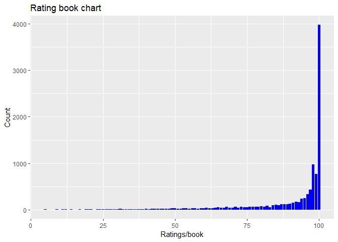

```r
a1 <- r1 %>%
  group_by(book_id) %>%
  summarize(no_of_ratings_per_book = n())

  ggplot(a1,aes((no_of_ratings_per_book )))+
  geom_bar(fill = "blue") +labs( y="Count", x="Ratings/book", title="Rating book chart")
```

**Insight:**

- This graph tells us that most of the popular books recieve higher number of ratings than the ones which are not popular

### 1.48 Genre Distribution chart

I look at how genres are distributed across my books

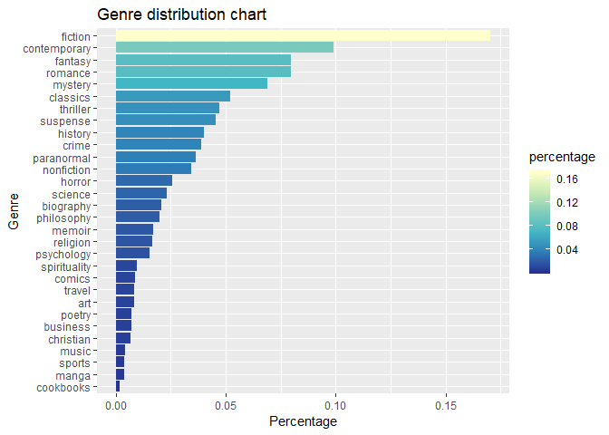

```r
genres <- str_to_lower(c("Art", "Biography", "Business", "Chick Lit", "Children's", "Christian", "Classics", "Comics", "Contemporary", "Cookbooks", "Crime", "Fantasy", "Fiction", "Gay and Lesbian", "Graphic Novels", "Historical Fiction", "History", "Horror", "Humor and Comedy", "Manga", "Memoir", "Music", "Mystery", "Nonfiction", "Paranormal", "Philosophy", "Poetry", "Psychology", "Religion", "Romance", "Science", "Science Fiction", "Self Help", "Suspense", "Spirituality", "Sports", "Thriller", "Travel", "Young Adult"))

available_genres <- genres[str_to_lower(genres) %in% tags$tag_name]
available_tags <- tags$tag_id[match(available_genres, tags$tag_name)]

gnr <- books_tags %>%
  filter(tag_id %in% available_tags) %>%
  group_by(tag_id) %>%
  summarize(n = n()) %>%
  ungroup() %>%
  mutate(sumN = sum(n), percentage = n / sumN) %>%
  arrange(-percentage) %>%
  left_join(tags, by = "tag_id")

gnr %>%
  ggplot(aes(reorder(tag_name, percentage), percentage, fill = percentage)) + geom_bar(stat = "identity") + coord_flip() + scale_fill_distiller(palette = 'YlGnBu') + labs(y = 'Percentage', x = 'Genre',title="Genre distribution chart")
```

**Insight:**

- My expectation was true from this datset, As expected fiction tops the chart with 16% followed by contemporary and fantasy, these contribute to over 35% of my books

### 1.49 Factors affecting rating of a book

I want to understand what affects my books ratings

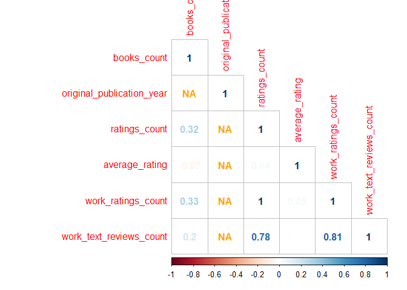

```r
cormat <- books %>% select("books_count","original_publication_year","ratings_count",
                  "average_rating","work_ratings_count","work_text_reviews_count")
corrplot(cor(cormat), type="lower",method="number",na.label = "NA",na.label.col = "orange")
```

**Observation:**

- My Initial theory is that book counts,authors,publication year, ratings count are some of the driving factors for rating
- We see here that average rating is not correlated with ratings_count at all which means that the popularity of the book does not affect my ratings of the book
- Generally it is assumed that the more editions of the book the higher the rating for the book would be but the data shows different results- there is negligible correlation between books count and average rating,however the correlation is negative

## Part 2: Algorithm Application

### 2.1 Data Preparation | UBCF

```r
 ##Step 1 : Spread the ratings dataframe##
##The datframe needs to be dcasted and convert in to a real rating matrix
m1 <- dcast(r2,user_id~book_id,value.var = "rating", na.rm=FALSE)
m1[is.na(m1)] <- 0
m1 <- m1[,-1]

###Step 2 : Convert in to sparse matrix
dimension_names <- list(user_id = sort(unique(r2$user_id)), book_id = sort(unique(r2$book_id)))
m1 <- as.matrix(m1)
dimnames(m1) <- dimension_names
m1 <- as(m1, "sparseMatrix")
m <- as(m1,"realRatingMatrix")

###Step 3 : Run User based collaborative filtering
Rec.model<- Recommender(m, method = "UBCF", param=list(method="pearson",nn=4))

##Step 4 : Making predictioon and Getting recommendation for a User
current <- "25703"
prediction <- predict(Rec.model, m[current, ], type = "ratings")
as(prediction, 'data.frame') %>%
  arrange(-round(rating)) %>% .[1:3,] %>%
  mutate(book_id = as.numeric(as.character(item))) %>%
  left_join(select(books, authors, title, book_id), by = "book_id") %>%
  select(-item,-authors,-book_id,-rating) %>%
  datatable(class = "display",escape = FALSE,rownames=FALSE, caption="Recommended Books table",options = list(dom = 't',scrollX = TRUE, autoWidth = FALSE))
```

| user | title |
| --- | --- |
| 25703 | Harry Potter and the Half-Blood Prince (Harry Potter, #6) |
| 25703 | Harry Potter and the Order of the Phoenix (Harry Potter, #5) |
| 25703 | Harry Potter and the Sorcerer's Stone (Harry Potter, #1) |

**Insights:**

- Ratings dataframe is transformed in to a realrating matrix and User based collaborative filtering is run on the Matrix to find recommendations
- Here we take an example of an USER 25703 and predict the books the user is going to like
- We obtained recommendation for USER 25703 would like Harry potter and the half blood prince

### 2.2 Cross-validation | Parameter tuning

```r
#Step 1 : Build a Scheme and algorithm list

scheme <- evaluationScheme(m[1:500,], method = "cross-validation", k = 10, given = -1, goodRating = 5)
algorithms <- list("random" = list(name = "RANDOM", param =NULL),
                   "UBCF_05" = list(name = "UBCF", param = list(nn = 5)),
                   "UBCF_10" = list(name = "UBCF", param = list(nn = 10)),
                   "UBCF_30" = list(name = "UBCF", param = list(nn = 30)),
                   "UBCF_50" = list(name = "UBCF", param = list(nn = 50))
                   )

#Step 2 : Use the above to evalute between models
results <- evaluate(scheme, algorithms, type="ratings")
```

**Insights:**

- Recommenderlab offers a great way to evaluate between algorithms,In order to do this I need to create and evaluationScheme and then an algorithm list and pass them togther in the evaluate command. I choose a 10 fold crossvalidation here with additonal parameters
- nn here is the tuneable parameter which is the number of most similar users used to calculate predictions. The parameter is varied from 5 ro 50
- Goodrating is the highest rating in my data and given = -1 means that the predictions are calculated from all but 1 ratings, and performance is evaluated for 1 for each user
- Further I have also added a random model for comparision which is more like a naive model

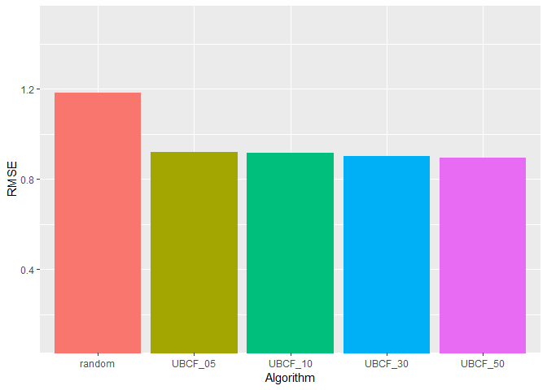

```r
#Step 3 : Calculate and Visualise the error

tmp <- lapply(results, function(x) slot(x, "results"))

res <- tmp %>%
  lapply(function(x) unlist(lapply(x, function(x) unlist(x@cm[ ,"RMSE"])))) %>%
  as.data.frame() %>%
  gather(key = "Algorithm", value = "RMSE")

res %>%
  ggplot(aes(Algorithm, RMSE, fill = Algorithm)) +
  geom_bar(stat = "summary") +
  coord_cartesian(ylim = c(0.1, 1.5)) + guides(fill = FALSE)
```

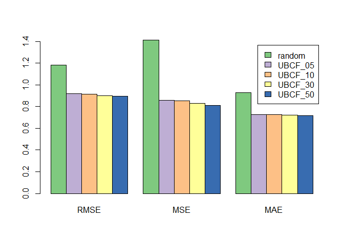

```r
###Step 4 : Let's look at different accuracy measures
colors <- brewer.pal(n = 5, name = "Accent")
plot(results, annotate = 1, legend="topleft",col=colors,xlab="Error Measure",ylab="Error",main="Different accuracy measure")
```

**Insights:**

- From the above graph it is seen that UBCF has the lowest RSME with 50 most simliar users, this is the cause that more neighbors I take in to consideration more accurate my model is hence this model is choosen to evaluate further
- From the second graph it is seen that among all the three measures namely RMSE, MAE and MSE UBCF_50 has the lowest error

```r
##Step 4 : Lets confirm the above by plotting the ROC curve
results1 <- evaluate(scheme, algorithms, n=c(1, 3, 5, 10, 15, 20))

avg_conf_matr <- function(results1) {
  temp <- results1 %>%
    getConfusionMatrix()  %>%
    as.list()
    as.data.frame(Reduce("+",temp) / length(temp)) %>%
    mutate(n = c(1, 3, 5, 10, 15, 20)) %>%
    select('n', 'precision', 'recall', 'TPR', 'FPR')
}

results_tbl <- results1 %>%
  map(avg_conf_matr) %>%
  enframe() %>% unnest()
```

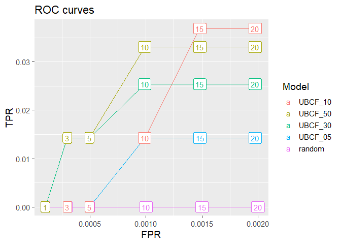

```r
results_tbl %>%
  ggplot(aes(FPR, TPR,
             colour = fct_reorder2(as.factor(name),
                      FPR, TPR))) +
  geom_line() +
  geom_label(aes(label = n))  +
  labs(title = "ROC curves", colour = "Model") +
  theme_grey(base_size = 14)+scale_fill_manual(values=c("green", "pink", "yellow","red","blue"))
```

**Insight:**

- ROC curve has been plotted and it is seen that the Area under curve(AUC) is the highest for UBCF_50 among the other neighbors and hence we choose nn=50 and start running different models
- Break points such as 1,3,5,10,15,20 has been added on the ROC curve for better understanding

### 2.3 Crossvalidation across | Models

```r
### Now lets look at a few other algorthims which are provided to us in the recommenderlab
recommenderRegistry$get_entry_names()
```

```
##  [1] "ALS_realRatingMatrix"            "ALS_implicit_realRatingMatrix"
##  [3] "ALS_implicit_binaryRatingMatrix" "AR_binaryRatingMatrix"
##  [5] "IBCF_binaryRatingMatrix"         "IBCF_realRatingMatrix"
##  [7] "POPULAR_binaryRatingMatrix"      "POPULAR_realRatingMatrix"
##  [9] "RANDOM_realRatingMatrix"         "RANDOM_binaryRatingMatrix"
## [11] "RERECOMMEND_realRatingMatrix"    "SVD_realRatingMatrix"
## [13] "SVDF_realRatingMatrix"           "UBCF_binaryRatingMatrix"
## [15] "UBCF_realRatingMatrix"
```

```r
####Running across various models####
scheme1 <- evaluationScheme(m[1:500,], method = "cross-validation", k = 10, given = -1, goodRating = 5)

algorithms1 <- list("popular" = list(name = "POPULAR", param =list(normalize = "Z-score")),
                   "UBCF_50" = list(name = "UBCF", param = list(nn = 50,normalize = "Z-score")),
                   "SVD" = list(name = "SVD", param = list(normalize = "Z-score")),
                   "SVDF" = list(name = "SVDF", param = list(normalize = "Z-score")))


results2 <- evaluate(scheme1, algorithms1, type="ratings")

tmp1 <- lapply(results2, function(x) slot(x, "results"))
res1 <- tmp1 %>%
  lapply(function(x) unlist(lapply(x, function(x) unlist(x@cm[ ,"RMSE"])))) %>%
  as.data.frame() %>%
  gather(key = "Algorithm", value = "RMSE")
```

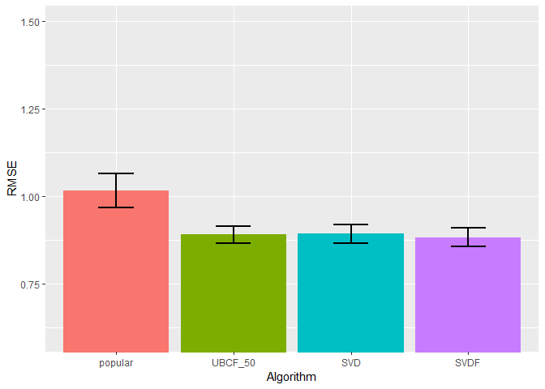

```r
res1 %>%
  mutate(Algorithm=factor(Algorithm, levels = c("popular", "UBCF_50", "SVD", "SVDF"))) %>%
  ggplot(aes(Algorithm, RMSE, fill = Algorithm)) + geom_bar(stat = "summary") +
  geom_errorbar(stat = "summary", width = 0.3, size = 0.8) + coord_cartesian(ylim = c(0.6, 1.5)) +
  guides(fill = FALSE)
```

### **2.4 Results:**

- Although from the graph above it is seen that SVDF has the lowest RMSE, the run time for SVDF is lot higher than UBCF. Since the RMSE values are identical I choose UBCF_50 to be my best performing algorithm and I can further use this to recommend books to users

### **Part 3: Shiny App**

Click [here](https://aashish2020.shinyapps.io/app4/) to visit the Shiny App

### **Part 4: Scope for Improvement:**

- An alternate way can be found for matrix transformation by writing a pre defined function which makes the algorithm run faster and takes less time
- Neural net implementation is the next algorithm that I would be running
- Shiny app can be created to make live recommendations. This cn be achieved if I am able to make the algorithm run faster
- Text mining can be employed to classify genre’s more accurately